# Pokemon

# Pokemon Aufgabe

```r
 library(readxl)
pokemon <- read_excel("F:/Alfatraining/Statistik mit R/t_test/uebung4.xlsx")
View(pokemon)
```

```r
library(psych)
describe(pokemon)
```

[output not shown]

|  | vars | n | mean | sd | median | trimmed | mad | min | max | range | skew | kurtosis | se |
| --- | --- | --- | --- | --- | --- | --- | --- | --- | --- | --- | --- | --- | --- |
| # | 1 | 800 | 362.81 | 208.34 | 364.5 | 362.99 | 263.16 | 1 | 721 | 720 | 0.00 | -1.17 | 7.37 |
| Name* | 2 | 800 | 400.50 | 231.08 | 400.5 | 400.50 | 296.52 | 1 | 800 | 799 | 0.00 | -1.20 | 8.17 |
| Type 1* | 3 | 800 | 10.47 | 5.58 | 11.0 | 10.69 | 7.41 | 1 | 18 | 17 | -0.28 | -1.19 | 0.20 |
| Type 2* | 4 | 414 | 9.79 | 4.42 | 9.0 | 9.79 | 4.45 | 1 | 18 | 17 | 0.11 | -0.88 | 0.22 |
| HP | 5 | 800 | 69.26 | 25.53 | 65.0 | 67.35 | 22.24 | 1 | 255 | 254 | 1.56 | 7.15 | 0.90 |
| Attack | 6 | 800 | 79.00 | 32.46 | 75.0 | 77.16 | 29.65 | 5 | 190 | 185 | 0.55 | 0.15 | 1.15 |
| Defense | 7 | 800 | 73.84 | 31.18 | 70.0 | 71.04 | 29.65 | 5 | 230 | 225 | 1.15 | 2.69 | 1.10 |
| Sp. Atk | 8 | 800 | 72.82 | 32.72 | 65.0 | 70.16 | 29.65 | 10 | 194 | 184 | 0.74 | 0.28 | 1.16 |
| Sp. Def | 9 | 800 | 71.90 | 27.83 | 70.0 | 69.98 | 29.65 | 20 | 230 | 210 | 0.85 | 1.60 | 0.98 |
| Speed | 10 | 800 | 68.28 | 29.06 | 65.0 | 67.25 | 31.13 | 5 | 180 | 175 | 0.36 | -0.25 | 1.03 |

[output cut: 2 more lines]

```r
count_legendary <- table(unlist(pokemon$Legendary))
count_legendary
```

```
FALSE  TRUE
  735    65
```

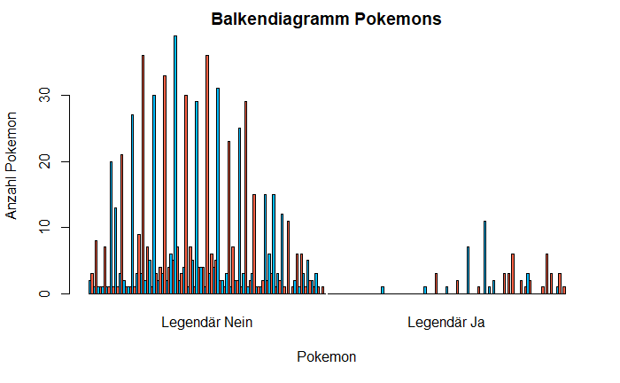

```r
counts<- table(Attack = pokemon$Attack, Legendary= pokemon$Legendary)

barplot(counts, main="Balkendiagramm Pokemons",
col=c("deepskyblue","tomato"),
ylab="Anzahl Pokemon",xlab = "Pokemon",
beside=T,
names.arg =c("Legendär Nein", "Legendär Ja"),
#legend = rownames(counts),
 args.legend = list(x = "topright"))
```

# 1) Hypothese

## ungerichtete Hypothese

H1: Es gibt einen Unterschied zwischen dem Angriff von legendären und Nicht-legendären Pokemon.
$$M_{L}≠M_{NL}$$
H0: Es gibt keinen Unterschied zwischen dem Angriff von legendären und Nicht-legendären Pokemon.
$$M_{L}= M_{NL}$$

## gerichtete Hypothese

H1: Der Angriff bei legendären ist höher als bei Nicht-legendären Pokemon.
$$M_{L} > M_{NL}$$

H0: Der Angriff bei legendären ist niedriger oder gleichhoch wie bei Nicht-legendären Pokemon.
$$M_{L} \leq M_{NL}$$

```r
nrow(pokemon)
```

```
[1] 800
```

# t-kritisch für die ungerichtete Hypothese

```r
# ungerichtete Hypothese
qt(0.975, df=798)
```

```
[1] 1.962941
```

# Voraussetzungen des t-Tests für unabhängige Stichproben

Die abhängige Variable ist min. intervallskaliert -> Angriff(AV)

Es liegt eine unabhängige Variable vor, mittels der die beiden zu vergleichenden Gruppen gebildet werden. -> Ja, Legendär und Nicht-Legendär

Das untersuchte Merkmal ist in den Grundgesamtheiten der beiden Gruppen normalverteilt -> siehe Histogramm

Homogenität der Varianzen: Die Gruppen kommen aus Grundgesamtheiten mit annähernd identischer Varianz -> siehe Levene-Test

Die einzelnen Messwerte sind voneinander unabhängig (das Verhalten einer Versuchsperson hat keinen Einfluss auf das Verhalten einer anderen) -> ist gegeben.